# Paso 1. Descarga, limpieza y preparación de datos para SDM

M.en C. Viridiana Lizardo

6 de agosto de 2024

# Introducción.

En este documento se describen los pasos para preparar un modelado de distribución de especies en R y se proporcionan referencias para aprender más sobre cada uno de las herramientas y los pasos.

El objetivo de este documento es:

- Dar un ejemplo reproducible que puedan modificar a su interés.
- Producir los archivos de registros que se usarán para modelar una especie:
  - training.csv
  - testing.csv
- Mapa descriptivo de lo anterior

# Paquetes requeridos

## Manejo de datos

El paquete`tidyverse` es una colección de paquetes de R diseñados para la ciencia de datos. Proporciona una gramática coherente y herramientas para manipulación y análisis de datos.

Es requerimiento **escencial** para poder reproducir este script, ya que se usa y abusa de el uso de las pipes (`%>%`), las cuales enfatizan una secuencia de acciones.

Más info aquí: [Tidyverse](https://www.tidyverse.org/)

```r
library(tidyverse)
library(BAT)
```

Para una clase sobre esta paquetería pueden ir a [esta clase en youtube](https://www.youtube.com/watch?v=PMwpuONWkYQ) o revisar [las diapositivas](https://rladiescuerna.github.io/meetup_julio_2022/presentacion.html#1) de la misma.

## Sistemas de Información Geográfica

Para datos *vectoriales*, se usa el paquete `sf`. Este permite leer, manipular y modificar datos geográficos en formato vectorial, utilizando el estándar Simple Features. Es una herramienta esencial para trabajar con datos geográficos en R.

Más info aquí: sf, [Geocomputation with R](https://r.geocompx.org/)

```r
library(sf)
```

Los mapas los haremos con `tmap` y su complemento `tmaptools`. Diseñados para la creación de mapas temáticos con una gramática similar a ggplot.

Más info aquí: [tmap](https://r-tmap.github.io/tmap/)

```r
library(tmap)
library(tmaptools)
```

## Obtención de registros de presencia

El paquete `rgbif` permite interactuar con la base de datos de la Global Biodiversity Information Facility (GBIF) para descargar y procesar datos de biodiversidad. Así como para obtener datos taxonómicos y estandarizar nombres científicos.

Más info aquí: [rgbif](https://docs.ropensci.org/rgbif/index.html)

```r
library(rgbif)
```

## Pre-procesado de datos

### Registros

El paquete `CoordinateCleaner` ayuda a identificar y limpiar errores en los datos de coordenadas espaciales. Lo hace de forma automatizada y basándose en la estructura de datos de GBIF.

Más info aquí: [CoordinateCleaner](https://ropensci.github.io/CoordinateCleaner/)

```r
library(CoordinateCleaner)
```

# Puntos de registro obtenidos de GBIF de *D. virginiana*

## Credenciales de GBIF

Necesitan crear cuenta en GBIF y tener a la mano los siguientes datos: - Usuario - contraseña - email

Guardar **PERMANENTEMENTE** en el .Renviron. Hagan esto en su computadora personal.

```r
install.packages("usethis")
usethis::edit_r_environ()

GBIF_USER= "your_gbif_username"
GBIF_PWD= "your_gbif_password"
GBIF_EMAIL= "your_email@example.com"

Sys.getenv("GBIF_USER")
```

Si no es su computadora, guarden las credenciales **temporalmente**.

```r
# Set your GBIF credentials
gbif_user <- "your_gbif_username"
gbif_pwd <- "your_gbif_password"
gbif_email <- "your_email@example.com"
```

## Obtener identificador único de la especie

[figure not shown]

Especie de interés.

Nos interesa verificar que el nombre sea válido ante la GBIF. Lo que vamos a extraer es el código único de la especie (`speciesKey`)

```r
sp_info <- rgbif::name_backbone('Didelphis virginiana')

glimpse(sp_info) # Función de tidyverse
```

```
Rows: 1
Columns: 23
$ usageKey       <int> 2439923
$ scientificName <chr> "Didelphis virginiana Kerr, 1792"
$ canonicalName  <chr> "Didelphis virginiana"
$ rank           <chr> "SPECIES"
$ status         <chr> "ACCEPTED"
$ confidence     <int> 99
$ matchType      <chr> "EXACT"
$ kingdom        <chr> "Animalia"
$ phylum         <chr> "Chordata"
$ order          <chr> "Didelphimorphia"
$ family         <chr> "Didelphidae"
$ genus          <chr> "Didelphis"
$ species        <chr> "Didelphis virginiana"
$ kingdomKey     <int> 1
$ phylumKey      <int> 44
$ classKey       <int> 359
$ orderKey       <int> 783
$ familyKey      <int> 5455
$ genusKey       <int> 7932087
$ speciesKey     <int> 2439923
$ synonym        <lgl> FALSE
$ class          <chr> "Mammalia"
$ verbatim_name  <chr> "Didelphis virginiana"
```

```r
species_key <- sp_info$speciesKey
```

## Descarga de datos

Se utiliza la función `occ_download`, deben tener sus credenciales guardadas. Al hacer esto se especifica claramente el origen de datos y se genera un DOI de la descarga que se citará en cualquier publicación resultante de esto.

```r
gbif_download <- occ_download(
  pred("taxonKey", species_key),
  pred("hasCoordinate", TRUE), # con coordenadas
  pred("hasGeospatialIssue", FALSE), # sin problemas espaciales
  pred_gte("year", 1950),  # a partir de 1950
  pred_in("basisOfRecord",'PRESERVED_SPECIMEN'), # tipo de registro
  # Quitar registros "no nativos"
  pred_or(pred_not(
    pred("establishmentMeans","MANAGED")),
    pred_not(pred_notnull("establishmentMeans"))),
  pred_or(pred_not(pred("establishmentMeans","INTRODUCED")),
          pred_not(pred_notnull("establishmentMeans"))),
  pred_or(pred_not(pred("establishmentMeans","INVASIVE")),
          pred_not(pred_notnull("establishmentMeans"))),
  pred_or(pred_not(pred("establishmentMeans","NATURALISED")),
          pred_not(pred_notnull("establishmentMeans"))),
  format = "SIMPLE_CSV"

  # solo agregar si no esta en .Renviron
  # user = gbif_user,
  # pwd = gbif_pwd,
  #email = gbif_email
)

# Esperar a que esté lista (pueden ser hasta 30 minutos)
occ_download_wait(gbif_download)
```

### Cargar datos

```r
gbif_result <- occ_download_get(gbif_download) %>%
  occ_download_import()
```

### Referencia de la descarga

```r
occ_download_meta(gbif_download) %>% gbif_citation()
```

```
$download
[1] "GBIF Occurrence Download https://doi.org/10.15468/dl.x324bk Accessed from R via rgbif (https://github.com/ropensci/rgbif) on 2024-08-05"

$datasets
NULL
```

# Limpiar los datos con `CoordinateCleaner`

```r
gbif_clean <- gbif_result %>%
  cc_dupl() %>% # duplicados
  cc_cap()  %>% # capitales
  cc_cen() %>% # centroides de países
  cc_equ() %>% # coordenadas iguales (ejemplo: -1,-1)
  cc_sea() %>% # en el mar
  cc_val() %>% # coordenadas inválidas
  cc_zero()
```

```
Testing zero coordinates
Testing coordinate validity
Testing sea coordinates
Testing equal lat/lon
Testing country centroids
Testing country capitals
Testing duplicates
Removed 1105 records.
Removed 10 records.
Removed 0 records.
Removed 0 records.
probando la URL 'https://naturalearth.s3.amazonaws.com/110m_physical/ne_110m_land.zip'
```

```
Removed 36 records.
Removed 0 records.
Removed 0 records.
```

## Resultado

```r
glimpse(gbif_clean)
```

```
Rows: 2,075
Columns: 50
$ gbifID                           <int64> 4.542697e-315, 4.542695e-315, 4.542691e-315, 4.542689e-…
$ datasetKey                       <chr> "22a66350-7947-4a49-84a3-39c7c1b0881f", "22a66350-7947-4a…
$ occurrenceID                     <chr> "urn:catalog:MSU:MR:MR.5689", "urn:catalog:MSU:MR:MR.7804…
$ kingdom                          <chr> "Animalia", "Animalia", "Animalia", "Animalia", "Animalia…
$ phylum                           <chr> "Chordata", "Chordata", "Chordata", "Chordata", "Chordata…
$ class                            <chr> "Mammalia", "Mammalia", "Mammalia", "Mammalia", "Mammalia…
$ order                            <chr> "Didelphimorphia", "Didelphimorphia", "Didelphimorphia", …
$ family                           <chr> "Didelphidae", "Didelphidae", "Didelphidae", "Didelphidae…
$ genus                            <chr> "Didelphis", "Didelphis", "Didelphis", "Didelphis", "Dide…
$ species                          <chr> "Didelphis virginiana", "Didelphis virginiana", "Didelphi…
$ infraspecificEpithet             <chr> "californica", "virginiana", "virginiana", "virginiana", …
$ taxonRank                        <chr> "SUBSPECIES", "SUBSPECIES", "SUBSPECIES", "SUBSPECIES", "…
$ scientificName                   <chr> "Didelphis virginiana californica Bennett, 1833", "Didelp…
```

[output cut: 37 more lines]

# Visualizar los datos

```r
tmap_mode('plot') # imagen estática
```

```
tmap mode set to plotting
```

## Limpiar datos atípicos de Colombia y Bolivia

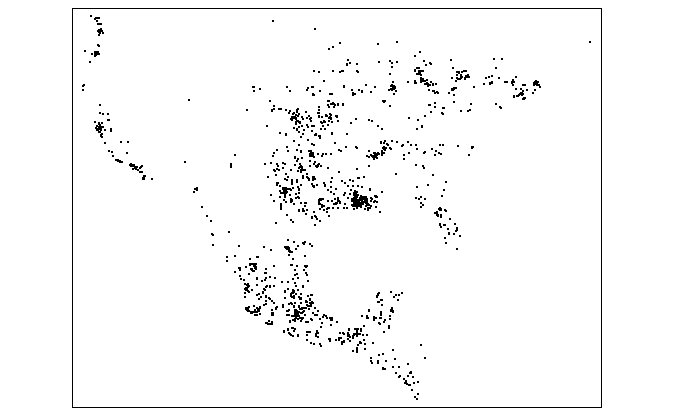

```r
gbif_cleaner <- gbif_clean %>% filter(!countryCode %in% c('CO', 'BO'))

occ_sf <- st_as_sf(gbif_cleaner, coords = c('decimalLongitude', 'decimalLatitude'),
         crs = 4326)


qtm(occ_sf)
```

# Separar en Training (80%) y Testing (20%)

Además, eliminamos todas las columnas con información que no es necesaria para el modelo y conservamos únicamente tres: especie, longitud y latitud.

## Training data

```r
set.seed(123) # para reproducibilidad

training <- gbif_cleaner %>%
  select(species, decimalLongitude, decimalLatitude) %>% #seleccionar columnas
  rownames_to_column('ID') %>% # agregar ID para cada punto
  sample_frac(0.80) # porcentaje de training

training
```

| ID | species | decimalLongitude | decimalLatitude |
| --- | --- | --- | --- |
| 526 | Didelphis virginiana | -87.71488 | 41.97280 |
| 195 | Didelphis virginiana | -96.62604 | 34.12013 |
| 1842 | Didelphis virginiana | -122.73303 | 48.98548 |
| 1142 | Didelphis virginiana | -100.46311 | 31.43954 |
| 1253 | Didelphis virginiana | -92.95500 | 16.68139 |
| 1268 | Didelphis virginiana | -94.43531 | 18.13780 |
| 1038 | Didelphis virginiana | -105.37683 | 22.46450 |
| 665 | Didelphis virginiana | -91.88396 | 30.03821 |
| 1627 | Didelphis virginiana | -100.31556 | 25.72417 |
| 1011 | Didelphis virginiana | -92.39270 | 31.17030 |

[output cut: 990 more lines]

## Testing data

```r
testing <- gbif_cleaner %>%
  select(species, decimalLongitude, decimalLatitude) %>% #seleccionar columnas
  rownames_to_column('ID') %>% # agregar ID para cada punto
  filter(!ID %in% training$ID)

testing
```

| ID | species | decimalLongitude | decimalLatitude |
| --- | --- | --- | --- |
| 3 | Didelphis virginiana | -84.44839 | 42.81855 |
| 7 | Didelphis virginiana | -102.81576 | 21.75106 |
| 15 | Didelphis virginiana | -84.55540 | 42.67450 |
| 21 | Didelphis virginiana | -105.04133 | 19.49529 |
| 22 | Didelphis virginiana | -106.41557 | 23.23653 |
| 25 | Didelphis virginiana | -85.38633 | 45.19133 |
| 42 | Didelphis virginiana | -84.61435 | 42.73245 |
| 43 | Didelphis virginiana | -84.47386 | 42.73684 |
| 47 | Didelphis virginiana | -84.47219 | 42.70425 |
| 53 | Didelphis virginiana | -102.86771 | 23.17600 |

[output cut: 405 more lines]

## Guardar datos

En la carpeta `data`

```r
training %>% select(-ID) %>% #quitar columna ID
  write.csv('data/training.csv', row.names = F) # Guardar en sin números de fila

testing %>% select(-ID) %>% write.csv('data/testing.csv', row.names = F)
```

# Mapa

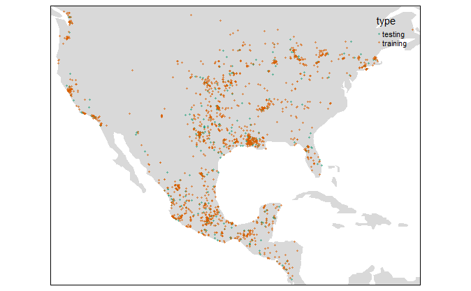